# ECE421_Assignment_5

**You need to submit 2 things:**

- On **Crowdmark**, answers to each question:
  - for questions without code, as usual (you can take a screenshot of your answer in the colab cell or write it down on a separate medium)
  - for questions with code, take a screenshot of the code and upload it to Crowdmark
- On **Quercus**, submit a ipynb file with your entire code

```python
# To convert .ipynb to html file
#%%shell
#jupyter nbconvert --to html /content/ECE421_Assignment_5.ipynb
```

# **Sentiment Analysis Using Gated-Recurrent Neural Networks**

In this assignment, we will use the IMDB dataset that contains the text of 50,000 movie reviews from the Internet Movie Database (IMDB) website. The label of each movie review is either positive or negative. An example of the input-output pair in this dataset is

"*I happen to run into this movie one night so I decided to watch it ! I was very pleased with the movie ... I thought it was a wonderful plot . It 's a great feeling knowing a deceased one has come back and you get that second chance to say what you want to say ! And this wife stayed devoted for 23 years ! ! ! I thought it was a great movie ! !*"

where its label, as you might expect, is "*positive*".

**In this assignment, we want to design a classifier that takes as input a review and outputs whether it is a positive or negative review about a movie.**

In the next two cells, we import some modules and also fix some constants for our implementation.

```python
import csv
from typing import Callable, Tuple

import jax.numpy as jn
import matplotlib.pyplot as plt
import numpy as np
from jax import lax
from tensorflow.keras.preprocessing.sequence import pad_sequences
from tensorflow.keras.preprocessing.text import Tokenizer
from tqdm import trange
from sklearn.model_selection import train_test_split
%pip --quiet install objax
import objax
from objax.typing import JaxArray


objax.random.DEFAULT_GENERATOR.seed(42)
np.random.seed(42)
```

```python
!gdown --id 11r58MB8wRBO1o1gEC-zxiADZIuwMnhf7
```

```python
max_vocab = 2000  # maximum number of words in the dictionary
max_len = 200  # maximum length of each review
embedding_size = 30  # size of embedding
num_hidden_units_GRU = 30  # GRU cells in the RNN layer
num_hidden_units = 60  # hidden unit of dense network after GRU

vocab_size = max_vocab
filename = 'IMDB Dataset.csv'
```

# How to find a representation of sentences?

In order to put the words into the machine learning algorithm the text data should be converted into a vector representation. The first approach that comes to mind is *one hot encoding*.

# One Hot Encoding

Assume that we count the number of english words in the Merriam-Webster dictionary, and it turns out that the total number of words is $N$. Then, a possible way to represent the words is to use binary vectors of size $N$. Each integer value is represented as a binary vector that is all zero values except the index of the integer, which is marked with a $1$. As an example let's say all the words in the dictionary consists of $\{$apple, orange, Milan,Rome$\}$. For this example, the one hot encoding is given by:

apple = $[1,0,0,0]$ \ orange = $[0,1,0,0]$ \ Milan = $[0,0,1,0]$ \ Rome = $[0,0,0,1]$

We can also represent each word by an integer: for instance in the above-mentioned example, the mapping is apple $\rightarrow$ 1, orange $\rightarrow$ 2, Milan $\rightarrow$ 3, Rome $\rightarrow$ 4.

When we are working with a dataset, a practical approach for one-hot encoding of the data is as follows:

1. First, we can create a dictionary which shows each word along with its frequency in the dataset. For example, if the sentence is "Put the books on the table." , we need to create a dictionary such that word_index["Put"] = 1; word_index["the"] = 2; word_index["books"] = 1; word_index["on"] = 1; word_index["table"] = 1.
2. Second, based on the maximum size of the vocabulary we want, we can sort the words based on their frequency and only pick the most frequent words of this maximum size of the vocabulary, and this creates our dictionary. So lower integer means more frequent word (often the first few are stop words because they appear a lot)
3. Then, we can assign an integer to each word in the dictionary, and represent each sentence as a sequence of integers.

The following function performs the above-mentioned steps for our IMDB dataset.

```python
def data_processing(filename, max_vocab, max_len):
  # filename: the name of the .csv file
  # max_vocab: The maximum number of words
  # max_len: The maximum length of a review
  messages = []  # list containing the reviews
  labels = []  # list containing the labels
  with open(filename, 'r') as file:
      reader = csv.reader(file)
      firstline = True
      for row in reader:
        if firstline:
            firstline = False
            continue
        else:
            messages.append(row[0])
            labels.append(int(row[1]=='positive'))

  tokenizer = Tokenizer(num_words=max_vocab)
  tokenizer.fit_on_texts(messages)
  messages_seq = tokenizer.texts_to_sequences(messages)
  data = pad_sequences(messages_seq, maxlen=max_len)
  train_size = 0.8
  messages_train, messages_valid_test, labels_train, labels_valid_test  = train_test_split(data, labels, train_size=train_size)
  messages_valid, messages_test, labels_valid, labels_test  = train_test_split(messages_valid_test, labels_valid_test, train_size=0.5)
  return np.array(messages_train), np.array(labels_train), np.array(messages_valid), np.array(labels_valid), np.array(messages_test), np.array(labels_test)
```

For the data_processing function, we used Tokenizer which is a class in keras.preprocessing.text. The following questions are about the different methods in this class. \

**Question 1** [1 points]: In your own words, explain what does "fit_on_texts" do? \

> Calling fit_on_texts maps each unique word in the in the file to a unique integer index so that the "dictionary" can be represented numerically. It does this by first turning all characters lower case and removing punctuation. Basically, calling tokenizer turns the text strings into a **set** of string words (no duplicates) where words are ordered from highest to lowest frequency, with ties being broken by which word appears first in the text. This indexing begins from i = 1 to i = N, where N is the number of unique words passed to the function, as seen in the below coding block.

```python
# Sample text data
texts = ["Here is one sample sentence.", "Another sample sentence."]

# Creating tokenizer & calling fit_on_texts
tokenizer = Tokenizer()
tokenizer.fit_on_texts(texts)

# Printing the word indexes
word_index = tokenizer.word_index
print(word_index)
```

```
{'sample': 1, 'sentence': 2, 'here': 3, 'is': 4, 'one': 5, 'another': 6}
```

**Question 2** [1 points]: In your own words, explain what does "texts_to_sequences" do? \

> texts_to_sequences converts the original text into its integer representation according to the word_indexes created by fit_on_texts. For example, since the second sentence in the above example is, "Another sample sentence.", mapping each word to its assigned index while maintaining their order gives you [6, 1, 2] since 6-->"another", 1-->"samples", & 2-->"sentence". This can be seen below using the same example text as before.

```python
# Printing the sequences
sequences = tokenizer.texts_to_sequences(texts)
print(sequences)
```

```
[[3, 4, 5, 1, 2], [6, 1, 2]]
```

**Question 3** [1 points]: In your own words, explain what does "pad_sequences" do, and why do we need it? \

> Calling pad_sequences makes it so all sequences or sentences can be presented by vectors of the same length, where the sequence is truncated if it exceeds maxlen or filled with zeros if it doesn't. Doing this is important for RNNs so that we can utilize vectorization, since we cannot perform parallel computations on vectors of different sizes.

```python
# Printing the padded sequences
padded_sequences = pad_sequences(sequences, maxlen=4, padding='post', truncating='post')
print(padded_sequences)
```

```
[[3 4 5 1]
 [6 1 2 0]]
```

In the next cell, we encode the data set using one-hot encoding, and split the dataset into the training set, validation set, and the test test.

```python
messages_train, labels_train, messages_valid, labels_valid, messages_test, labels_test = data_processing(filename, max_vocab, max_len)
```

**Question 4** [1 points]: Print one of the input in the training set and explain your observation? Does it match with what you expected?

> Printed below you can see the 10th training input as well as its shape. This output looks as expected since we are given a array of length 200 (since max_len was set to 200) where the message has been padded by zeros since it was shorter than max length. Also as expected we are given the text input sentence / sequence in terms of its mapped integer index values, determined by fit_on_texts.

```python
print(messages_train[10])
print(messages_train[10].shape)
```

```
[   0    0    0    0    0    0    0    0    0    0    0    0    0    0
    0    0    0    0    0    0    0    0    0    0    0    0    0    0
    0    0    0    0    0    0    0    0    0    0    0    0    0    0
    0    0    0    0    0    0    0    0    0    0    0    0    0    0
    0    0    0   10  511    1  229    4    1  615  171  228   18  858
  228    8   10   13    1  714  929  225   96  106  644    4 1583  498
 1336   36  676    5  676  175  140    2  175    1  920    2   14  106
  644    4   87  256    2 1472  514   68    1 1381   12    1   64   66
 1894   75 1010   14    3  334  858 1086  228    2   91   82    3  785
   14    3    4  112  201  164    2  324   33 1041 1058    1  917    7
    7    9  233   25   75   51  427   43   99    4    1  102   66  231
    5  131   12   10 1931  554  302    8  106   79  104  159   38   43
    1  272  292    1   27   10   66  277  228   82    1   19   15   32
 1720 1198   19   30  224   92  489   13    8    1  203  274    9  292
  125 1268  369 1831]
(200,)
```

# Embedding Layer

Imagine that we have 80,000 unique words in a text classification problem and we select to preprocess the text as explained above. For instance, a sentence "i love you" or ['i', 'love', 'you'] can be shown as a matrix of size (3 , 80000) where its elements is all zeros except from 3 elements that correspond to those words. In the case that we want to extract the feature using recurrent neural netowk, the input size should be the size of $80,000$ in which only three entries are non-zero!

Instead, we can use the observation that since our goal is to extract feature from a sentence, we might be able to construct a mapping so that the words whose meanings are similar map to the same vector. One possible approach to do this is to perform this maaping using a simple matrix multiplication that transforms words into their corresponding word embeddings or turns positive integers (indexes) into dense vectors of fixed size, where the size of embedding $\ll$ size of the vocabualry.

Please watch this short video to gain better understanding of the embedding layer:

https://www.coursera.org/lecture/nlp-sequence-models/learning-word-embeddings-APM5s

Since Objax does not have embedding layer module in it, we need to write our own module. One implementaiton of the embedding layer is as follows.

```python
class Embed(objax.Module):
    def __init__(self, size: int, latent: int, init: Callable = objax.nn.init.xavier_truncated_normal):
        self.w = objax.TrainVar(init((size, latent)))

    def __call__(self, x: JaxArray) -> JaxArray:
        return self.w.value[x]
```

**Question 5: [1 points]** Briefly explain how `__init__` and `__call__` functions work when the input is a sentence?

> When the input is a sentence **init** assigns the weight of Embed to be some value randomly sampled from a normal Xavier distribution with standard deviation = sqrt[2/(#inputs+#outputs)] according to [365 Data Science](https://365datascience.com/tutorials/machine-learning-tutorials/what-is-xavier-initialization/). The **call** function returns the weight values of a specific x JaxArray as a JaxArray. Thus when the input is a sentence calling **init** assigns the sentence a weight to input of size=size and output of size=latent, while **call** returns those assigned weights.

# Gated Recurrent Unit Cell

GRUs are a family of the recurrent neural networks used for processing of the sequential data. In this assignment, we want to use GRU for the sentiment analysis.

The forward pass of a Gated Recurrent Unit is defined by the following equations:

1. $z_t = \text{sigmoid} (W_z x_t + U_z h_{t-1} + b_z)$
2. $r_t = \text{sigmoid} (W_r x_t + U_r h_{t-1} + b_r)$
3. $\hat{h}_t = \text{tanh} (W_h x_t + U_h (r_t \odot h_{t-1}) + b_h)$
4. $h_t = (1-z_t)\odot h_{t-1} + z_t \odot \hat{h}_t$

where the operator ${\displaystyle \odot }$ denotes the Hadamard product, and

- $x_{t}$: input vector
- $h_{t}$: output vector
- ${\hat {h}}_{t}$: candidate activation vector
- $z_{t}$: update gate vector
- $r_{t}$: reset gate vector
- $W_z$, $W_r$, $W_h$ , $U_z$, $U_r$, $U_h$, $b_z$ ,$b_r$, $b_h$ are parameter matrices and vectors.

The schematic of a GRU cell is show below (taken from Wikipedia). Here $\hat{y}_t$ is the same as $h_t$, and $\sigma$ is sigmoid function.

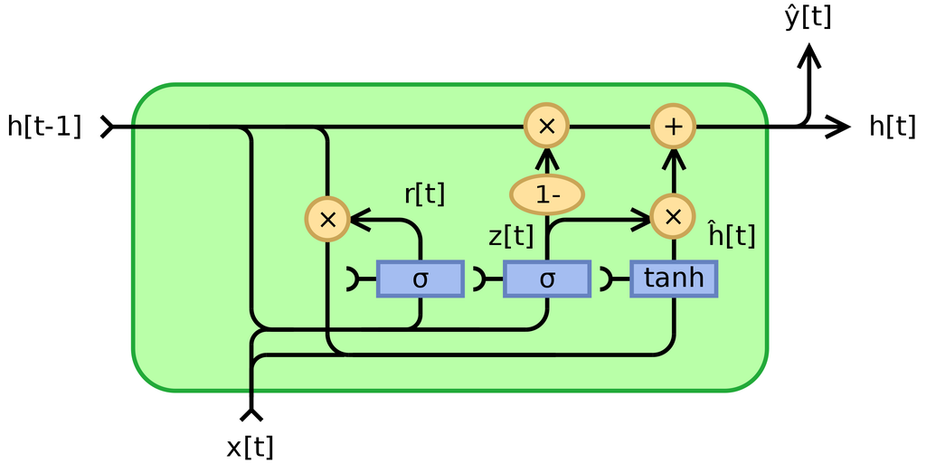

To learn more about GRU, please watch these short videos:

https://www.youtube.com/watch?v=8HyCNIVRbSU

https://www.youtube.com/watch?v=pYRIOGTPRPU

Similar to the embedding layer, GRU module is not implemented in the Objax. The following is an implementation of the GRU cell in the Objax.

**Question 6[3 points]:** In the following implementation, complete the `__call__` function.

```python
class GRU(objax.Module):
    def __init__(self, nin: int, nout: int,
                 init_w: Callable = objax.nn.init.xavier_truncated_normal,
                 init_b: Callable = objax.nn.init.truncated_normal):
        self.update_w = objax.TrainVar(init_w((nin, nout)))
        self.update_u = objax.TrainVar(init_w((nout, nout)))
        self.update_b = objax.TrainVar(init_b((nout,), stddev=0.01))
        self.reset_w = objax.TrainVar(init_w((nin, nout)))
        self.reset_u = objax.TrainVar(init_w((nout, nout)))
        self.reset_b = objax.TrainVar(init_b((nout,), stddev=0.01))
        self.output_w = objax.TrainVar(init_w((nin, nout)))
        self.output_u = objax.TrainVar(init_w((nout, nout)))
        self.output_b = objax.TrainVar(init_b((nout,), stddev=0.01))

    def __call__(self, x: JaxArray, initial_state: JaxArray) -> Tuple[JaxArray, JaxArray]:
        def scan_op(state: JaxArray, x: JaxArray) -> JaxArray:  # State must come first for lax.scan
            update_gate = objax.functional.sigmoid(jn.matmul(x, self.update_w.value) + jn.matmul(state, self.update_u.value) + self.update_b.value)

            reset_gate = objax.functional.sigmoid(jn.matmul(x, self.reset_w.value) + jn.matmul(state, self.reset_u.value) + self.reset_b.value)

            output_gate = objax.functional.tanh(jn.matmul(x, self.output_w.value) + jn.matmul(jn.multiply(reset_gate, state), self.output_u.value) + self.output_b.value)

            return (1-update_gate) * state + (update_gate) * output_gate, 0   # we don't use the output, return 0.

        return lax.scan(scan_op, initial_state, x.transpose((1, 0, 2)))[0]
```

**Questions 7** (bonus)[5 points]: With an example, explain in detail what does lax.scan function do, and what it is useful for?

> lax.scan allows you to carry over results from your previous iteration to your next one. For example, calling lax.scan for a scan_fn which adds new inputs to the previous gives the following:

```python
# summing function
def sum_fxn(prev, curr):
    return prev + curr, prev + curr

# input & initial state
input = jn.array([1, 2, 3, 4, 5])
init_state = jn.array(0)

# cummulative sum
cum_sum, _ = lax.scan(sum_fxn, init_state, input)

print("Input:", input)
print("Cumulative Sum:", cum_sum)
```

```
Input: [1 2 3 4 5]
Cumulative Sum: 15
```

> This is important for RNNs because it remembers the previous state which is one of the inputs for our next state, and updates as it goes.

# The classifier

The structure of the proposed classifier is as follows:

- The input is a vector whose elements are integers in the interval $\{$1,...,max_vocab$\}$ of length max_len.
- Then, the embedding layer converts this vector into a matrix of size (max_len,embedding_size).
- Then, we feed each row of this matrix into the GRU cell. The size of the output vector of the GRU is num_hidden_units_GRU.
- The output of the GRU is feed into a fully-connected layer with num_hidden_units neurons and ReLU activation function.
- Finally, we have the output layer which is a fully-connected layer with two outputs corresponding to the positive or negative label.

**Question 8** [3 points]: implement the described classifier using `objax.nn.Sequential`.

```python
# Creating instance of layer classes

# input (shape=[max_len,])
# --> embeded_layer (input = input, output = matrix [max_vocab, embedding_size])
# --> each row matrix into GRU cell (output vector = [num_hidden_units_GRU,])
# --> fully connected layer (# neurons = num_hidden_units), activation = ReLU
# --> output (2 outputs corrosponding to positive or negative label)

gru_rnn = objax.nn.Sequential([Embed(size=max_vocab, latent=embedding_size),
                               GRU(nin=embedding_size, nout=num_hidden_units_GRU),
                               objax.nn.Linear(num_hidden_units_GRU, num_hidden_units),
                               objax.functional.relu,
                               objax.nn.Linear(num_hidden_units, 2)

])
```

You can print the structure as well as the number of the parameters of the each layer using the following line of codes.

```python
print(f'{" Network ":-^79}')
print(gru_rnn.vars())
```

```
----------------------------------- Network -----------------------------------
(Sequential)[0](Embed).w         60000 (2000, 30)
(Sequential)[1](GRU).update_w      900 (30, 30)
(Sequential)[1](GRU).update_u      900 (30, 30)
(Sequential)[1](GRU).update_b       30 (30,)
(Sequential)[1](GRU).reset_w       900 (30, 30)
(Sequential)[1](GRU).reset_u       900 (30, 30)
(Sequential)[1](GRU).reset_b        30 (30,)
(Sequential)[1](GRU).output_w      900 (30, 30)
(Sequential)[1](GRU).output_u      900 (30, 30)
(Sequential)[1](GRU).output_b       30 (30,)
(Sequential)[2](Linear).b           60 (60,)
(Sequential)[2](Linear).w         1800 (30, 60)
(Sequential)[4](Linear).b            2 (2,)
(Sequential)[4](Linear).w          120 (60, 2)
+Total(14)                       67472
```

**Question 9** [3 points]: Draw the classifier architecture diagram. For GRU consider drawing the unrolled version. You do not need to draw the internal structure of the GRU.

[figure not shown]

**Question 10**[1 point]: Construct an SGD optimizer using objax optimizers package.

```python
## Your implementaiton of the optimizer should go here
opt = objax.optimizer.SGD(gru_rnn.vars())
```

Then, we define the loss function, training operation function, and the evaluation function.

```python
def loss_function(x: JaxArray, y: JaxArray):
    logits = gru_rnn(x, initial_state=jn.zeros((x.shape[0], num_hidden_units_GRU)))
    return objax.functional.loss.cross_entropy_logits_sparse(logits, y).sum()


gv = objax.GradValues(loss_function, gru_rnn.vars())


@objax.Function.with_vars(gv.vars() + opt.vars())
def train_op(x: JaxArray, y: JaxArray, lr: float):
    g, loss = gv(x, y)
    opt(lr, g)
    return loss


train_op = objax.Jit(train_op)
eval_op = objax.Jit(lambda x: gru_rnn(x, initial_state=jn.zeros((x.shape[0], num_hidden_units_GRU))),
                    gru_rnn.vars())
```

The next function is a helper for computing the accuracy.

```python
def accuracy(data_loader):
    """Compute the accuracy for a provided data loader"""
    acc_total = 0
    x, y = data_loader
    batch_size_acc = 500
    for batch_idx in np.array_split(np.arange(len(x)), len(x) // batch_size_acc):
        x_batch, target_class = x[batch_idx], y[batch_idx]
        predicted_class = eval_op(x_batch).argmax(1)
        acc_total += (predicted_class == target_class).sum()
    return acc_total / len(x)
```

**Question 11** [4 points]: Write the training loop to train the model. In each epoch, record the training accuracy and the validation accuracy. Also, at the end of the training report the accuracy on the test set. Please use the training set to train the model, the validation set to monitor accuracy during training, and then the test set once after training is complete to measure the final generalization of the model.

```python
learning_rate = 1e-3 # learning rate
num_epochs = 20 # number of epochs
batch_size = 250  # batch size
training_data = (messages_train, labels_train)
validation_data = (messages_valid, labels_valid)
test_data = (messages_test, labels_test)
```

```python
# Training loop for base protocol (SGD)
val_acc = []
train_acc = []

def train_gru(EPOCHS = num_epochs, BATCH = batch_size, LEARNING_RATE = learning_rate):
  train_acc_epoch = []
  val_acc_epoch = []

  for epoch in range(EPOCHS):
      train_acc = 0      # training accuracy per batch
      val_acc = 0        # validation accuracy per batch

      # shuffle training examples to remove correlation
      train_indices = np.arange(len(messages_train))
      np.random.shuffle(train_indices)

      # training
      for it in range(0, messages_train.shape[0], BATCH):
          batch = train_indices[it: it+BATCH]
          train_op(messages_train[batch], labels_train[batch], LEARNING_RATE)

      train_acc = accuracy(training_data)
      val_acc = accuracy(validation_data)

      train_acc_epoch.append(train_acc)
      val_acc_epoch.append(val_acc)

      print('GRU RNN: Epoch %04d  Training Accuracy %.2f Validation Accuracy %.2f' % (epoch + 1, 100*train_acc, 100*val_acc))

  # Final test accuracy
  test_acc = accuracy(test_data)
  print(f'GRU RNN: Test Accuracy %.2f' %(test_acc*100))


  #Plot training & validation loss
  plt.title("Train vs Validation Accuracy")
  plt.plot(train_acc_epoch, label="Train")
  plt.plot(val_acc_epoch, label="Validation")
  plt.plot(EPOCHS-1, test_acc, '*', label="Test")
  plt.xlabel("Epoch")
  plt.ylabel("Accuracy (%)")
  plt.legend(loc='best')
  plt.show()
```

**Question 12:[1 points]** Plot the training accuracy and the validation accuracy versus the number of epochs. What is the generalization gap between the test and training?

```
GRU RNN: Epoch 0001  Training Accuracy 58.68 Validation Accuracy 57.44
GRU RNN: Epoch 0002  Training Accuracy 61.76 Validation Accuracy 60.98
GRU RNN: Epoch 0003  Training Accuracy 56.33 Validation Accuracy 56.58
GRU RNN: Epoch 0004  Training Accuracy 68.18 Validation Accuracy 65.62
GRU RNN: Epoch 0005  Training Accuracy 72.32 Validation Accuracy 71.62
GRU RNN: Epoch 0006  Training Accuracy 73.24 Validation Accuracy 71.30
GRU RNN: Epoch 0007  Training Accuracy 75.58 Validation Accuracy 74.92
GRU RNN: Epoch 0008  Training Accuracy 68.43 Validation Accuracy 67.10
GRU RNN: Epoch 0009  Training Accuracy 77.89 Validation Accuracy 77.14
GRU RNN: Epoch 0010  Training Accuracy 71.80 Validation Accuracy 70.52
GRU RNN: Epoch 0011  Training Accuracy 62.72 Validation Accuracy 61.84
GRU RNN: Epoch 0012  Training Accuracy 64.36 Validation Accuracy 63.50
GRU RNN: Epoch 0013  Training Accuracy 77.49 Validation Accuracy 76.64
GRU RNN: Epoch 0014  Training Accuracy 82.30 Validation Accuracy 81.74
GRU RNN: Epoch 0015  Training Accuracy 80.65 Validation Accuracy 80.06
GRU RNN: Epoch 0016  Training Accuracy 84.87 Validation Accuracy 84.52
GRU RNN: Epoch 0017  Training Accuracy 75.82 Validation Accuracy 74.42
GRU RNN: Epoch 0018  Training Accuracy 83.51 Validation Accuracy 82.94
GRU RNN: Epoch 0019  Training Accuracy 87.34 Validation Accuracy 86.66
GRU RNN: Epoch 0020  Training Accuracy 74.34 Validation Accuracy 73.94
GRU RNN: Test Accuracy 75.08
```

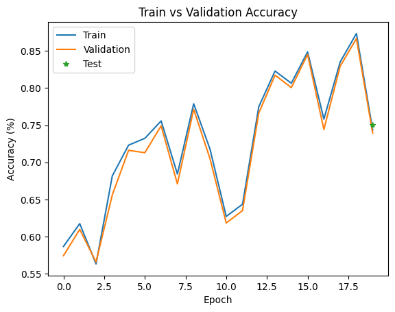

```python
train_gru()
```

# Comparing SGD with Adam

**Question 13** [4 points]: Train the same model with the same parameters using the Adam optimizer instead of the SGD. Do not forgot to initialize the network before training, otherwise the previous model will continue training from the final model parameters rather than start from a fresh set of random weight initialization values.

```python
# Define (again) your model here
gru_rnn2 = objax.nn.Sequential([Embed(size=max_vocab, latent=embedding_size),
                               GRU(nin=embedding_size, nout=num_hidden_units_GRU),
                               objax.nn.Linear(num_hidden_units_GRU, num_hidden_units),
                               objax.functional.relu,
                               objax.nn.Linear(num_hidden_units, 2)

])
```

```python
## Your implementaiton of the optimizer should go here
opt2 = objax.optimizer.Adam(gru_rnn2.vars())
```

You will also need the following functions.

```python
def loss_function(x: JaxArray, y: JaxArray):
    logits = gru_rnn2(x, initial_state=jn.zeros((x.shape[0], num_hidden_units_GRU)))
    return objax.functional.loss.cross_entropy_logits_sparse(logits, y).sum()


gv2 = objax.GradValues(loss_function, gru_rnn2.vars())


@objax.Function.with_vars(gv2.vars() + opt2.vars())
def train_op(x: JaxArray, y: JaxArray, lr: float):
    g, loss = gv2(x, y)
    opt2(lr, g)
    return loss


train_op = objax.Jit(train_op)
eval_op = objax.Jit(lambda x: gru_rnn2(x, initial_state=jn.zeros((x.shape[0], num_hidden_units_GRU))),
                    gru_rnn2.vars())
```

```python
learning_rate = 1e-3
num_epochs = 20
batch_size = 250
training_data = (messages_train, labels_train)
validation_data = (messages_valid, labels_valid)
test_data = (messages_test, labels_test)
```

```python
# Training loop for ADAM Optimizer
val_acc = []
train_acc = []

def train_gru2(EPOCHS = num_epochs, BATCH = batch_size, LEARNING_RATE = learning_rate):
  train_acc_epoch = []
  val_acc_epoch = []

  for epoch in range(EPOCHS):
      train_acc = 0      # training accuracy per batch
      val_acc = 0        # validation accuracy per batch

      # shuffle training examples to remove correlation
      train_indices = np.arange(len(messages_train))
      np.random.shuffle(train_indices)

      # training
      for it in range(0, messages_train.shape[0], BATCH):
          batch = train_indices[it: it+BATCH]
          train_op(messages_train[batch], labels_train[batch], LEARNING_RATE)

      train_acc = accuracy(training_data)
      val_acc = accuracy(validation_data)

      train_acc_epoch.append(train_acc)
      val_acc_epoch.append(val_acc)

      print('GRU RNN2: Epoch %04d  Training Accuracy %.2f Validation Accuracy %.2f' % (epoch + 1, 100*train_acc, 100*val_acc))

  # Final test accuracy
  test_acc = accuracy(test_data)
  print(f'GRU RNN2: Test Accuracy %.2f' %(test_acc*100))


  #Plot training & validation loss
  plt.title("Train vs Validation Accuracy")
  plt.plot(train_acc_epoch, label="Train")
  plt.plot(val_acc_epoch, label="Validation")
  plt.plot(EPOCHS-1, test_acc, '*', label="Test")
  plt.xlabel("Epoch")
  plt.ylabel("Accuracy (%)")
  plt.legend(loc='best')
  plt.show()
```

**Question 14** [1 points]: Plot the training accuracy and validation accuracy versus the epochs, and compare your results with the case that you trained the network using SGD. What is the generalization gap for this case?

```
GRU RNN2: Epoch 0001  Training Accuracy 88.49 Validation Accuracy 87.42
GRU RNN2: Epoch 0002  Training Accuracy 89.76 Validation Accuracy 87.46
GRU RNN2: Epoch 0003  Training Accuracy 90.95 Validation Accuracy 87.82
GRU RNN2: Epoch 0004  Training Accuracy 91.16 Validation Accuracy 87.66
GRU RNN2: Epoch 0005  Training Accuracy 92.08 Validation Accuracy 88.00
GRU RNN2: Epoch 0006  Training Accuracy 92.28 Validation Accuracy 88.14
GRU RNN2: Epoch 0007  Training Accuracy 92.69 Validation Accuracy 87.52
GRU RNN2: Epoch 0008  Training Accuracy 93.10 Validation Accuracy 87.64
GRU RNN2: Epoch 0009  Training Accuracy 93.71 Validation Accuracy 88.02
GRU RNN2: Epoch 0010  Training Accuracy 94.54 Validation Accuracy 88.06
GRU RNN2: Epoch 0011  Training Accuracy 95.01 Validation Accuracy 88.40
GRU RNN2: Epoch 0012  Training Accuracy 95.50 Validation Accuracy 87.80
GRU RNN2: Epoch 0013  Training Accuracy 95.48 Validation Accuracy 88.00
GRU RNN2: Epoch 0014  Training Accuracy 94.24 Validation Accuracy 87.30
GRU RNN2: Epoch 0015  Training Accuracy 96.45 Validation Accuracy 87.64
GRU RNN2: Epoch 0016  Training Accuracy 96.58 Validation Accuracy 88.10
GRU RNN2: Epoch 0017  Training Accuracy 97.05 Validation Accuracy 87.32
GRU RNN2: Epoch 0018  Training Accuracy 97.24 Validation Accuracy 87.32
GRU RNN2: Epoch 0019  Training Accuracy 96.83 Validation Accuracy 86.48
GRU RNN2: Epoch 0020  Training Accuracy 97.34 Validation Accuracy 87.54
GRU RNN2: Test Accuracy 87.10
```

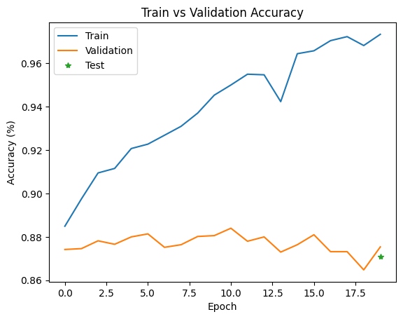

```python
train_gru2()
```

**Questions 15** [1 points]: Briefly explain how Adam optimizer works and compare it with the SGD optimizaer.

> Adam combines momentum with adaptive learning rates to update the weights based on past gradients. The adaptive learning rate is applied to each individual parameter, and keeps track of their variances. The routine is as follows:
- mean = decay1 *mean + (1-decay1)* grad(Loss)
- velocity = decay2*velocity + (1-decay2)* grad(Loss)^2
- mean_mod = mean / (1-decay1^num_steps)
- velo_mod = velocity / (1-decay2^num_steps)
- w = w - learning rate / [sqrt(velo_mod) + epsilon] * mean_mod

> Here epsilon is just to prevent dividing by zero. Thus Momentum optimization uses the hyperparameters of learning rate and a momentum term (p), while Adam uses learning rate, epsilon, and two "momentum" terms which I have denoted decay1 and decay2.

> This is unlike the SGD optimizer which does not "remember" past gradients, making it such that each time the weights update it is completely dependent on the samples in the current batch. Another important aspect of the Adam optimizer is that it converges to an optimal solution more quickly compared to SGD.

# Early Stopping

**Questions 16** [3 points]: This time implement the early stopping method with a patience window. All the parameters are the same as the previous section. Also, set the patience window to 5 epochs.

```python
# Your implementation of the model should go here
gru_rnn3 = objax.nn.Sequential([Embed(size=max_vocab, latent=embedding_size),
                               GRU(nin=embedding_size, nout=num_hidden_units_GRU),
                               objax.nn.Linear(num_hidden_units_GRU, num_hidden_units),
                               objax.functional.relu,
                               objax.nn.Linear(num_hidden_units, 2)
])
```

```python
## Your implementaiton of the optimizer should go here
opt3 = objax.optimizer.SGD(gru_rnn3.vars())
```

You will also need the following functions.

```python
def loss_function(x: JaxArray, y: JaxArray):
    logits = gru_rnn3(x, initial_state=jn.zeros((x.shape[0], num_hidden_units_GRU)))
    return objax.functional.loss.cross_entropy_logits_sparse(logits, y).sum()


gv3 = objax.GradValues(loss_function, gru_rnn3.vars())


@objax.Function.with_vars(gv3.vars() + opt3.vars())
def train_op(x: JaxArray, y: JaxArray, lr: float):
    g, loss = gv3(x, y)
    opt3(lr, g)
    return loss


train_op = objax.Jit(train_op)
eval_op = objax.Jit(lambda x: gru_rnn3(x, initial_state=jn.zeros((x.shape[0], num_hidden_units_GRU))),
                    gru_rnn3.vars())
```

```python
learning_rate = 1e-3
num_epochs = 20
batch_size = 250
max_patience_window = 5
training_data = (messages_train, labels_train)
validation_data = (messages_valid, labels_valid)
test_data = (messages_test, labels_test)
```

```python
# Training loop for early stopping protocol
val_acc = []
train_acc = []

def train_gru3(EPOCHS = num_epochs, BATCH = batch_size, LEARNING_RATE = learning_rate, WINDOW = max_patience_window):
  train_acc_epoch = []
  val_acc_epoch = []

  best_val_acc = 0
  window_counter = 0
  final_epoch = EPOCHS

  for epoch in range(EPOCHS):
      train_acc = 0      # training accuracy per batch
      val_acc = 0        # validation accuracy per batch

      # shuffle training examples to remove correlation
      train_indices = np.arange(len(messages_train))
      np.random.shuffle(train_indices)

      # training
      for it in range(0, messages_train.shape[0], BATCH):
          batch = train_indices[it: it+BATCH]
          train_op(messages_train[batch], labels_train[batch], LEARNING_RATE)

      train_acc = accuracy(training_data)
      val_acc = accuracy(validation_data)

      train_acc_epoch.append(train_acc)
      val_acc_epoch.append(val_acc)

      print('GRU RNN3: Epoch %04d  Training Accuracy %.2f Validation Accuracy %.2f' % (epoch + 1, 100*train_acc, 100*val_acc))

      # early stopping conditions
      if best_val_acc >= val_acc:
        window_counter += 1
        if window_counter == max_patience_window:
          final_epoch = epoch
          break
      else: # current validation accuracy better than past best validation accuracy
        window_counter = 0
        best_val_acc = val_acc


  # Final test accuracy
  test_acc = accuracy(test_data)
  print(f'GRU RNN3: Test Accuracy %.2f' %(test_acc*100))


  #Plot training & validation loss
  plt.title("Train vs Validation Accuracy")
  plt.plot(train_acc_epoch, label="Train")
  plt.plot(val_acc_epoch, label="Validation")
  plt.plot(final_epoch-1, test_acc, '*', label="Test")
  plt.xlabel("Epoch")
  plt.ylabel("Accuracy (%)")
  plt.legend(loc='best')
  plt.show()
```

```
GRU RNN3: Epoch 0001  Training Accuracy 58.01 Validation Accuracy 57.12
GRU RNN3: Epoch 0002  Training Accuracy 62.77 Validation Accuracy 61.92
GRU RNN3: Epoch 0003  Training Accuracy 65.08 Validation Accuracy 62.86
GRU RNN3: Epoch 0004  Training Accuracy 65.16 Validation Accuracy 65.22
GRU RNN3: Epoch 0005  Training Accuracy 65.11 Validation Accuracy 63.54
GRU RNN3: Epoch 0006  Training Accuracy 74.79 Validation Accuracy 73.90
GRU RNN3: Epoch 0007  Training Accuracy 74.51 Validation Accuracy 72.84
GRU RNN3: Epoch 0008  Training Accuracy 62.55 Validation Accuracy 61.00
GRU RNN3: Epoch 0009  Training Accuracy 63.36 Validation Accuracy 62.10
GRU RNN3: Epoch 0010  Training Accuracy 76.93 Validation Accuracy 75.22
GRU RNN3: Epoch 0011  Training Accuracy 78.50 Validation Accuracy 77.02
GRU RNN3: Epoch 0012  Training Accuracy 80.16 Validation Accuracy 79.12
GRU RNN3: Epoch 0013  Training Accuracy 72.14 Validation Accuracy 71.92
GRU RNN3: Epoch 0014  Training Accuracy 82.54 Validation Accuracy 82.34
GRU RNN3: Epoch 0015  Training Accuracy 77.15 Validation Accuracy 76.90
GRU RNN3: Epoch 0016  Training Accuracy 83.27 Validation Accuracy 82.56
GRU RNN3: Epoch 0017  Training Accuracy 85.05 Validation Accuracy 84.48
GRU RNN3: Epoch 0018  Training Accuracy 86.28 Validation Accuracy 86.26
GRU RNN3: Epoch 0019  Training Accuracy 85.30 Validation Accuracy 85.02
GRU RNN3: Epoch 0020  Training Accuracy 84.99 Validation Accuracy 83.92
GRU RNN3: Test Accuracy 84.26
```

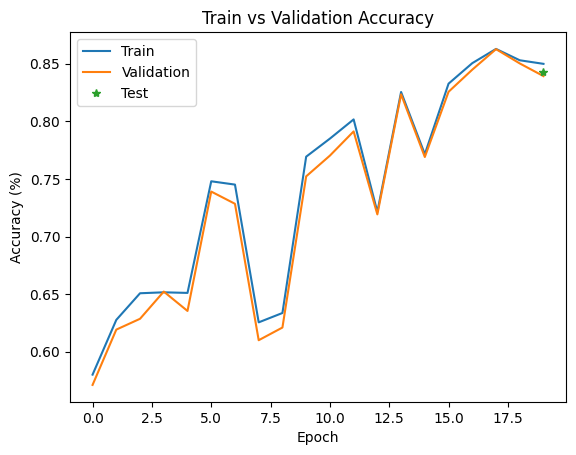

```python
train_gru3()
```

**Question 17**[1 points]: Report the best validation accuracy and the test accuracy of your best model.

# Model cards

Our invited guest lecturer Deborah Raji presented her research about model cards as part of her lecture. In this last question, you are encouraged to read about model cards in [the publication by Mitchell et al.](https://arxiv.org/abs/1810.03993) co-authored by Deborah Raji.

**Question 18** [3 points] Write a model card for the model you developed in this assignment. Your card should at least contain 3 sections described in Figure 1 of the [paper by Mitchell et al.](https://arxiv.org/abs/1810.03993): Model Details, Intended Use, Metrics.

# **Model Card - Positive and Negative Movie Review Classification**

**Model Details**: *Basic information about the model*

- Developed by Rachel Chan, student at University of Toronto, November 2023, v2.
- Recurrent Neural Network with Embed-GRU-FC-ReLU-FC architecture trained using Adam optimizer.
- Trained to classify positive and negative movie reviews.

**Intended Use**: *Use cases that were envisioned during development*

- Intended to be used to predict if review left on movie is positive or negative. Possible use cases include creating a movie rating based on ratio of positive to negative reviews.
- Not intended to detect overly or reasonably malicious reviews for filtering. Ie not intented to filter out "troll" reviews.

**Evaluation Data**: *Details on the dataset(s) used for the quantitative analyses in the card*

- Model evaluated using test set containing 10% of IMDB dataset, totalling to 5000 samples.
- Validation data comprised another 10% of IMDB dataset, used to evaluate model during each training Epoch.

>